[Richard N. Goodman](https://rngoodman.github.io/)

# Co-occurrence analysis of AMR genes

Richard Goodman

2023-11-03

This analysis takes a binary table of AMR genes present in a defined set of genomes from abricate and creates a co-occurrence matrix and subsequent analysis of the co-occurrence interactions between AMR genes across the genomes.

# Loading packages

```r
library(tidyverse)
library(pheatmap)
library(RColorBrewer)
library(igraph)
library(readr)
library(cooccur)
library(reshape2)
library(pheatmap)
library(RColorBrewer)
```

# Reading in data

```r
abricate_output = read_csv("data/all_abricate_773_Ec_Kp_CHL_Resfinder_L60_T90.csv")

drug_class = read_csv("data/resfinder_phenotype_table_edit.csv")

ab_tab = abricate_output

# Make sense of dataset

head(ab_tab)
```

```
## # A tibble: 6 × 15
##   `#FILE`     SEQUENCE     START    END STRAND GENE  COVERAGE COVERAGE_MAP GAPS
##   <chr>       <chr>        <dbl>  <dbl> <chr>  <chr> <chr>    <chr>        <chr>
## 1 26141-1-134 .26141_1_1… 158811 160043 -      mdf(… 1-1233/… ===========… 0/0
## 2 26141-1-134 .26141_1_1…    558   1346 -      aadA… 1-789/7… ===========… 0/0
## 3 26141-1-134 .26141_1_1…   1477   1950 -      dfrA… 1-474/4… ===========… 0/0
## 4 26141-1-134 .26141_1_1…    489   1121 -      catB… 1-633/6… ===========… 0/0
## 5 26141-1-134 .26141_1_1…   1259   2089 -      blaO… 1-831/8… ===========… 0/0
## 6 26141-1-134 .26141_1_1…   2220   2819 -      aac(… 1-600/6… ===========… 0/0
## # ℹ 6 more variables: `%COVERAGE` <dbl>, `%IDENTITY` <dbl>, DATABASE <chr>,
## #   ACCESSION <chr>, PRODUCT <chr>, RESISTANCE <chr>
```

```r
class(ab_tab)
```

```
## [1] "spec_tbl_df" "tbl_df"      "tbl"         "data.frame"
```

# Wrangling the abricate table

## Pre-processing the dataset

First duplicates must be removed from the dataset. These cause issues in downstream analysis.

```r
rm_duplicates = function(ab_tab)
{

  # First Remove duplicates
  # These cause issues with creating a lit rather than a dataframe
  # When compared against the database there can sometimes be duplciates

  # arrange and group by ab_tab
  ab_tab_unique <- ab_tab %>%
    arrange(GENE, -`%COVERAGE`) %>%
    group_by(GENE)

  # Check the colnames
  colnames(ab_tab_unique)

  # Check the duplicates
  duplicated(ab_tab_unique[c("#FILE","GENE")])
  print("Duplicates found:")
  print(c(which(duplicated(ab_tab_unique[c("#FILE","GENE")]) == TRUE))) # see which contain duplicates

  # Remove columns that contain duplicates in FILE, GENE and COVERAGE
  ab_tab_unique <- ab_tab[!duplicated(ab_tab_unique[c("#FILE","GENE")]),] #using colnames
  #ab_tab_unique <- ab_tab_unique[!duplicated(ab_tab_unique[c(1,2)]),] #using col numbers


  # Check whether duplicates have been delted
  print("Duplicates remaining:")
  print(which(duplicated(ab_tab_unique[c("#FILE","GENE")]) == TRUE)) # see which contain duplicates

  {
    return(ab_tab_unique)
  }
}


# Run function
ab_tab_unique = rm_duplicates(ab_tab)
```

```
## [1] "Duplicates found:"
##  [1] 1640 1789 2297 2463 4681 4685 5413 5580 6256 7477 7743 7997 8223 8492 8494
## [16] 8496 8498 8501 8503 8505 8507 8510 8513 8519 8531 8534 8537 8539 8541 8543
## [31] 8550 8564 8567 8571 8575 8577 8580 8582 8586 8588 8929 9661
## [1] "Duplicates remaining:"
##  [1]  608 2662 2663 4920 4921 4922 5806 5822 5904 5929 5987 6064 6113 6143 6197
## [16] 6247 6352 6417 6509 6868 6869 6981 7016 7073 7090 7151 7197 7395 7839 7912
## [31] 7982 8120 8166 8307 8322 8358 8389 8538 9709 9758
```

```r
rename_catB4 = function(ab_tab)
{

  # Rename any genes called catB3_1 with a % cverage lower than in the GENE column
  ab_tab_new <- mutate(ab_tab, GENE = ifelse(GENE == "catB3_1" & "%COVERAGE" < 90, "catB4", GENE))
  test = ab_tab_new %>% filter(GENE == "catB4")
  print("amount of catB4 found:")
  print(nrow(test))

  {
    return(ab_tab_new)
  }
}


ab_tab_unique = rename_catB4(ab_tab_unique)
```

```
## [1] "amount of catB4 found:"
## [1] 237
```

## Creating a count table

Next we make a count table of the AMR genes to display it in a way in which we can make it into a co-occurence table.

```r
mk_count_table = function(ab_tab)
{
  # Funtion to make the Abricate table wide
  # Create a new value from original ab_tab to wide count table
  wide = ab_tab %>%
    # select strain, gene and resistance and rename
    select("#FILE", GENE, RESISTANCE) %>%
    # rename
    rename(gene = "GENE",
           file = "#FILE",
           resistance = "RESISTANCE") %>%
    # count genes vs strains
    count(file, gene) %>%
    # Convert to wide table with genes as column headers and n as values
    pivot_wider(names_from = gene,
                values_from = n)

  # Shorten strain names (remove the unnecessary string)
  wide$file = gsub(".fa", "", wide$file)
  wide$file = gsub("_assembled.fasta", "", wide$file)

  {
    return(wide)
  }
}

# Run function
wide = mk_count_table(ab_tab_unique)


# Check
head(wide)
```

```
## # A tibble: 6 × 176
##   file    `aac(3)-IId_1` `aac(6')-Ib-cr_1` aadA5_1 `aph(3'')-Ib_5` `aph(6)-Id_1`
##   <chr>            <int>             <int>   <int>           <int>         <int>
## 1 26141-…              1                 1       1               1             1
## 2 26141-…              1                NA       1              NA            NA
## 3 26141-…              1                 1       1               1             1
## 4 26141-…             NA                NA       1               1             1
## 5 26141-…             NA                NA      NA               1             1
## 6 26141-…             NA                NA       1               1             1
## # ℹ 170 more variables: `blaCTX-M-15_1` <int>, `blaOXA-1_1` <int>,
## #   `blaTEM-1B_1` <int>, catB3_2 <int>, dfrA17_1 <int>, `mdf(A)_1` <int>,
## #   `mph(A)_2` <int>, sul2_3 <int>, `tet(A)_6` <int>, `blaCTX-M-27_1` <int>,
## #   sul1_5 <int>, sul2_2 <int>, aadA2_1 <int>, catA1_1 <int>, dfrA12_8 <int>,
## #   `tet(B)_2` <int>, `aac(3)-IIa_1` <int>, catB4 <int>,
## #   `blaCTX-M-14b_1` <int>, `ant(3'')-Ia_1` <int>, dfrA1_8 <int>,
## #   sul2_13 <int>, dfrA14_1 <int>, sul2_6 <int>, `blaSHV-12_1` <int>, …
```

```r
# Check
nrow(wide)
```

```
## [1] 772
```

Next convert this count table to a dataframe and matrix.

```r
# Converts to dataframe
count_to_dataframe = function(wide)
{
  wide = wide

  # make the genenames a variable
  rows = wide$file

  # Remove the file column
  wide3 = wide %>% select(-file)

  # name the rows as strains
  rownames(wide3) = rows

  # convert to dataframe
  d = as.data.frame(wide3)

  # convert na to 0
  d[is.na(d)] = 0

  #name rows
  rownames(d) = rows

  # convert to matrix
  d = d


  {
    return(d)
  }
}

d = count_to_dataframe(wide)

# Converts to matrix
count_to_mat = function(wide)
{
  wide = wide

  # make the genenames a variable
  rows = wide$file

  # Remove the file column
  wide3 = wide %>% select(-file)

  # name the rows as strains
  rownames(wide3) = rows

  # convert to dataframe
  d = as.data.frame(wide3)

  # convert na to 0
  d[is.na(d)] <- 0

  # name rows
  rownames(d) = rows

  # convert to matrix
  mat = as.matrix(d)


  {
    return(mat)
  }
}

# Run Function
mat = count_to_mat(wide)


# Check output
head(mat)
nrow(mat)
class(mat)
mat
colnames(mat)
```

# Using the cooccur package

The [cooccur package](https://griffithdan.github.io/pages/code_and_data/cooccur.html) implements the probabilistic mode of species co-occurrence from Veech 2013[^1]. Here we are using it to analyse the co-occurence of AMR genes instead of species.

The statistics use the observed probability of co-occurrence and the expected probability of co-occurrence to create two p values `p_lt` and `p_gt`.

`p_lt` is the probability that the two species would co-occur at a frequency less than the observed number of co-occurrence sites if the two species were distributed randomly (independently) of one another.

`p_gt` is the probability of co-occurrence at a frequency greater than the observed frequency.

For the plotting, if `p_gt` is greater than 0.05 (that is not significant) then it’s named 0, if not it’s named 1.

If p_lt is greater than 0.05 (that is not significant) then it’s named 0, if not it’s named -1.

- If a co-occurrence is 1 then it is labelled positive (blue)
- If a co-occurrence is 0 then it is labelled random (grey)
- If a co-occurrence is -1 it is labelled negative (orange)

## Creating a cooccur object

```r
# Transpose so gene names are the rows
# We need this to allow for a cooccur object
d_t = t(d)

cooccur.ESBL.genes <- cooccur(d_t,
                           type = "spp_site",
                           thresh = TRUE,
                           spp_names = TRUE)
```

## Checking a cooccur object

```r
class(cooccur.ESBL.genes)
```

```
## [1] "cooccur"
```

```r
summary(cooccur.ESBL.genes)
```

```
## Call:
## cooccur(mat = d_t, type = "spp_site", thresh = TRUE, spp_names = TRUE)
##
## Of 15225 species pair combinations, 12528 pairs (82.29 %) were removed from the analysis because expected co-occurrence was < 1 and 2697 pairs were analyzed
##
## Cooccurrence Summary:
```

```
##        Species          Sites       Positive       Negative         Random
##          175.0          772.0          607.0          703.0         1387.0
## Unclassifiable Non-random (%)
##            0.0           48.6
## attr(,"class")
## [1] "summary.cooccur"
```

## Plotting cooccurence using cooccur function

```r
cooccur_object = cooccur.ESBL.genes

    ##
    allargs <- match.call(expand.dots = TRUE)
    plotrand <- allargs$plotrand
    plotrand <- ifelse(test = is.null(plotrand),yes = FALSE,no = plotrand)
    randsummary<- allargs$randsummary
    randsummary <- ifelse(test = is.null(randsummary),yes = FALSE,no = randsummary)

    ##

    # Change as necessary - this is the number of genes in our case 169 for all
    dim = cooccur_object$species
    #
    comat_pos = matrix(nrow=dim,ncol=dim)
    comat_neg = comat_pos

    # Change as necessary - this is the full results table
    co_tab <- cooccur_object$result
    #

    # Create co_occurrence
    for (i in 1:nrow(co_tab)){
      comat_pos[co_tab[i,"sp1"],co_tab[i,"sp2"]] <- co_tab[i,"p_gt"]
      comat_pos[co_tab[i,"sp2"],co_tab[i,"sp1"]] <- co_tab[i,"p_gt"]

      row.names(comat_pos[co_tab[i,"sp2"],co_tab[i,"sp1"]])

    }
    for (i in 1:nrow(co_tab)){
      comat_neg[co_tab[i,"sp1"],co_tab[i,"sp2"]] <- co_tab[i,"p_lt"]
      comat_neg[co_tab[i,"sp2"],co_tab[i,"sp1"]] <- co_tab[i,"p_lt"]
    }

    # Join positive and negative cooccurence matrix and label as 0.05, 0 or -1
    comat <- ifelse(comat_pos>=0.05,0,1) + ifelse(comat_neg>=0.05,0,-1)
    colnames(comat) <- 1:dim
    row.names(comat) <- 1:dim

    # Name the co-occurence matrix

    colnames(comat) = unique(cooccur_object$spp.names)
    rownames(comat) = unique(cooccur_object$spp.names)

    #ind <- apply(comat, 1, function(x) all(is.na(x)))
    #comat <- comat[!ind,]
    #ind <- apply(comat, 2, function(x) all(is.na(x)))
    #comat <- comat[,!ind]

    comat[is.na(comat)] <- 0

    origN <- nrow(comat)

    # SECTION TO REMOVE SPECIES INTERACTION WITH NO OTHERS

    #rmrandomspp <- function(orimat,plotrand = FALSE,randsummary = FALSE){
    if(plotrand == FALSE){
      ind <- apply(comat, 1, function(x) all(x==0))
      comat <- comat[!ind,]
      ind <- apply(comat, 2, function(x) all(x==0))
      comat <- comat[,!ind]
      #ind <- apply(orimat, 1, function(x) all(x==0))
      #orimat <- orimat[!ind,]
      #ind <- apply(orimat, 2, function(x) all(x==0))
      #orimat <- orimat[,!ind]
    }
    #return(orimat)
    #}

    #comat <- rmrandomspp(orimat = comat, dots)
    #_____________________________________

    postN <- nrow(comat)


    ##comat <- comat[order(rowSums(comat)),]
    ##comat <- comat[,order(colSums(comat))]

    #comat <- rmrandomspp(orimat = comat, ...)

    #ind <- apply(comat, 1, function(x) all(x==0))
    #comat <- comat[!ind,]
    #ind <- apply(comat, 2, function(x) all(x==0))
    #comat <- comat[,!ind]

    ind <- apply(comat, 1, function(x) all(x==0))
    comat <- comat[names(sort(ind)),]
    ind <- apply(comat, 2, function(x) all(x==0))
    comat <- comat[,names(sort(ind))]

    #comat
    data.m = melt(comat)
    colnames(data.m) <- c("X1","X2","value")
    data.m$X1 <- as.character(data.m$X1)
    data.m$X2 <- as.character(data.m$X2)

    meas <- as.character(unique(data.m$X2))

    dfids <- subset(data.m, X1 == X2)

    X1 <- data.m$X1
    X2 <- data.m$X2

    df.lower = subset(data.m[lower.tri(comat),],X1 != X2)

    ##### testing the rand summary
    if(randsummary == FALSE){
    }else{
      dim <- nrow(comat)
      ext.dim <- round(dim*0.2,digits = 0)
      if(ext.dim<0){ext.dim<-1}
      placehold <- paste("ext_", rep(c(1:ext.dim),each = dim), sep="")

      randcol.df <- data.frame(
        X1 = placehold,
        X2 = rep(meas,times = ext.dim),
        value = rep(x = c(-2), times = dim*ext.dim))

      df.lower <- rbind(df.lower,randcol.df)
      meas <- c(meas,unique(placehold))
    }
```

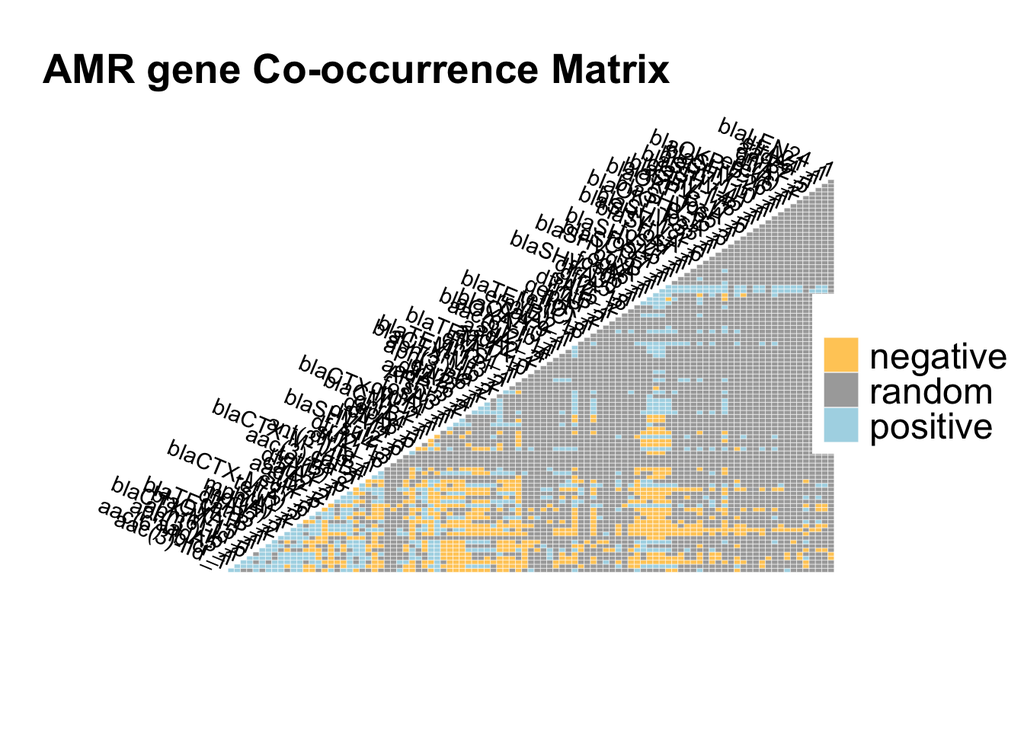

```r
    #_______________________

    X1 <- df.lower$X1
    X2 <- df.lower$X2
    value <- df.lower$value



    ####
    if(randsummary == FALSE){
      p <- ggplot(df.lower, aes(X1, X2)) + geom_tile(aes(fill = factor(value,levels=c(-1,0,1))), colour ="white")
      p <- p + scale_fill_manual(values = c("#FFCC66","dark gray","light blue"), name = "", labels = c("negative","random","positive"),drop=FALSE) +
        theme(axis.text.x = element_blank(),axis.text.y = element_blank(),axis.ticks = element_blank(),plot.title = element_text(vjust=-4,size=20, face="bold"),panel.background = element_rect(fill='white', colour='white'),panel.grid.major = element_blank(), panel.grid.minor = element_blank(),legend.position = c(0.9, 0.5),legend.text=element_text(size=18)) +
        ggtitle("AMR gene Co-occurrence Matrix") +
        xlab("") + ylab("") +
        scale_x_discrete(limits=meas, expand = c(0.3, 0),drop=FALSE) +
        scale_y_discrete(limits=meas, expand = c(0.3, 0),drop=FALSE)
      p <- p + geom_text(data=dfids,aes(label=X1),hjust=1,vjust=0,angle = -22.5)#, color="dark gray")


    }else{

      p <- ggplot(df.lower, aes(X1, X2)) + geom_tile(aes(fill = factor(value,levels=c(-1,0,1,-2))), colour ="white")
      p <- p + scale_fill_manual(values = c("#FFCC66","dark gray","light blue","light gray"), name = "", labels = c("negative","random","positive","random"),drop=FALSE) +
        theme(axis.text.x = element_blank(),axis.text.y = element_blank(),axis.ticks = element_blank(),plot.title = element_text(vjust=-4,size=20, face="bold"),panel.background = element_rect(fill='white', colour='white'),panel.grid.major = element_blank(), panel.grid.minor = element_blank(),legend.position = c(0.9, 0.5),legend.text=element_text(size=18)) +
        ggtitle("Species Co-occurrence Matrix") +
        xlab("") + ylab("") +
        scale_x_discrete(limits=meas, expand = c(0.3, 0),drop=FALSE) +
        scale_y_discrete(limits=meas, expand = c(0.3, 0),drop=FALSE)
      p <- p + geom_text(data=dfids,aes(label=X1),hjust=1,vjust=0,angle = -22.5)#, color="dark gray")

      dim <- nrow(comat)
      ext_x <- dim + 0.5 #(ext.dim/2)
      ext_y <- dim + 1
      nrem <- origN - postN
      randtext <- paste(nrem, " completely\nrandom species")
      ext_dat <- data.frame(ext_x=ext_x,ext_y=ext_y,randtext=randtext)

      p <- p + geom_text(data=ext_dat,aes(x = ext_x,y = ext_y,label=randtext),hjust=0,vjust=0, color="dark gray")
    }
    ####

    p
```

Save the co-occurence matrix as “comat”.

```r
 write.csv(comat, file = "out_tabs/CoccuR_cooccurence_matrix.csv")
```

## Plotting cooccurence using pheatmap

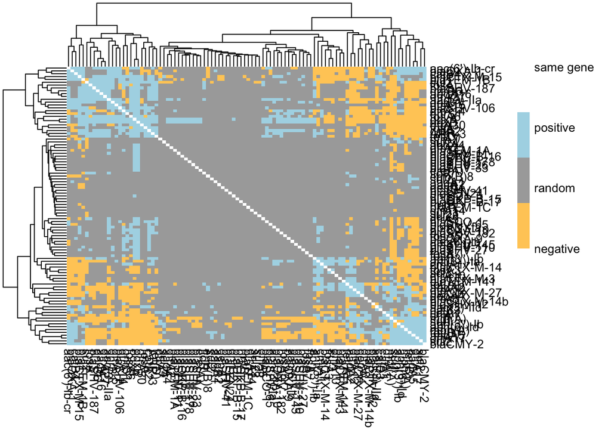

```r
# Check comat object

comat_pheatmap = comat

colnames(comat_pheatmap) = gsub("_1", "", colnames(comat_pheatmap))
colnames(comat_pheatmap) = gsub("_2", "", colnames(comat_pheatmap))
colnames(comat_pheatmap) = gsub("_3", "", colnames(comat_pheatmap))
colnames(comat_pheatmap) = gsub("_4", "", colnames(comat_pheatmap))
colnames(comat_pheatmap) = gsub("_5", "", colnames(comat_pheatmap))
colnames(comat_pheatmap) = gsub("_6", "", colnames(comat_pheatmap))
colnames(comat_pheatmap) = gsub("_7", "", colnames(comat_pheatmap))
colnames(comat_pheatmap) = gsub("_8", "", colnames(comat_pheatmap))

rownames(comat_pheatmap) = gsub("_1", "", rownames(comat_pheatmap))
rownames(comat_pheatmap) = gsub("_2", "", rownames(comat_pheatmap))
rownames(comat_pheatmap) = gsub("_3", "", rownames(comat_pheatmap))
rownames(comat_pheatmap) = gsub("_4", "", rownames(comat_pheatmap))
rownames(comat_pheatmap) = gsub("_5", "", rownames(comat_pheatmap))
rownames(comat_pheatmap) = gsub("_6", "", rownames(comat_pheatmap))
rownames(comat_pheatmap) = gsub("_7", "", rownames(comat_pheatmap))
rownames(comat_pheatmap) = gsub("_8", "", rownames(comat_pheatmap))

colnames(comat_pheatmap) = gsub("catB3_2", "catB3", colnames(comat_pheatmap))
rownames(comat_pheatmap) = gsub("catB3_2", "catB3", rownames(comat_pheatmap))

diag(comat_pheatmap) = 2

pheatmap(mat = comat_pheatmap,
         color = c("#FFCC66", "dark gray", "light blue", "white"),
         cluster_cols = TRUE,
         cluster_rows = TRUE,
         clustering_distance_cols = "euclidean",
         clustering_distance_rows = "euclidean",
         clustering_method = "complete",
         fontsize = 10,
         legend_breaks = c(-1, 0, 1, 2),
         legend_labels = c("negative", "random", "positive", "same gene"))
```

### subsetting from probability table table

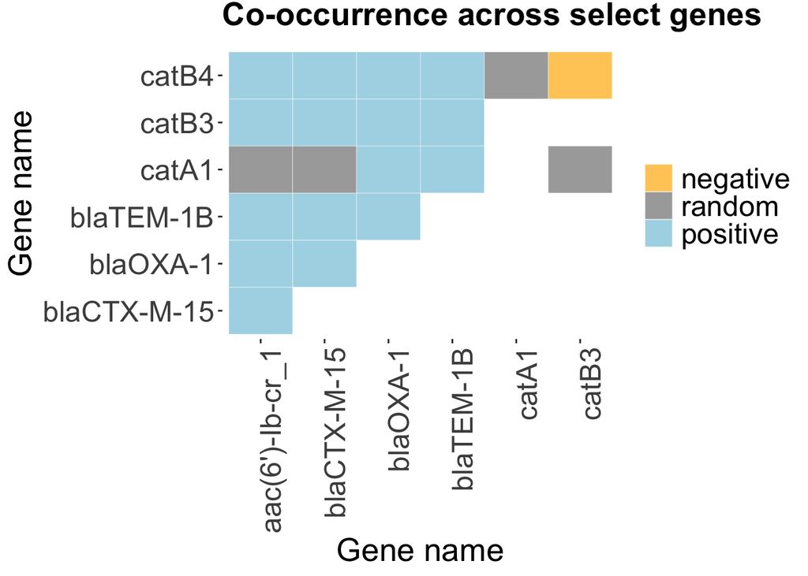

```r
# sp1 - Numeric label giving the identity of species 1, assigned based on the order in the input matrix
# sp2 - Numeric label for species 2
# sp1_inc - Number of sites (or samples) that have species 1
# sp2_inc - Number of sites that have species 2
# obs_cooccur - Observed number of sites having both species
# prob_cooccur - Probability that both species occur at a site
# exp_cooccur - Expected number of sites having both species
# p_lt - Probability that the two species would co-occur at a frequency less than the observed number of co-occurrence sites if the two species were distributed randomly (independently) of one another
# p_gt - Probability of co-occurrence at a frequency greater than the observed frequency
# sp1_name - If species names were specified in the community data matrix this field will contain the supplied name of sp1
# sp2_name - The supplied name of sp2

prob.table.ESBL.genes = prob.table(cooccur.ESBL.genes)

prob.table.ESBL.genes.filter = prob.table.ESBL.genes

prob.table.ESBL.genes.filter = prob.table.ESBL.genes.filter %>%
  filter(sp1_name == "blaCTX-M-15_1" |
           sp1_name == "blaOXA-1_1" |
           sp1_name == "blaTEM-1B_1" |
           sp1_name == "catA1_1"|
           sp1_name == "catB3_2" |
           sp1_name == "catB4" |
           sp1_name == "aac(6')-Ib-cr_1")


prob.table.ESBL.genes.filter.full = prob.table.ESBL.genes %>%
  filter(sp1_name == "blaCTX-M-15_1" |
           sp1_name == "blaOXA-1_1" |
           sp1_name == "blaTEM-1B_1" |
           sp1_name == "catA1_1"|
           sp1_name == "catB3_2" |
           sp1_name == "catB4" |
           sp1_name == "aac(6')-Ib-cr_1") %>%
  filter(sp2_name == "blaCTX-M-15_1" |
           sp2_name == "blaOXA-1_1" |
           sp2_name == "blaTEM-1B_1" |
           sp2_name == "catA1_1"|
           sp2_name == "catB3_2" |
           sp2_name == "catB4" |
           sp2_name == "aac(6')-Ib-cr_1")


# Rename sp1_name
prob.table.ESBL.genes.filter.full$sp1_name = gsub("blaCTX-M-15_1", "blaCTX-M-15", prob.table.ESBL.genes.filter.full$sp1_name)
prob.table.ESBL.genes.filter.full$sp1_name = gsub("blaOXA-1_1", "blaOXA-1", prob.table.ESBL.genes.filter.full$sp1_name)
prob.table.ESBL.genes.filter.full$sp1_name = gsub("blaTEM-1B_1", "blaTEM-1B", prob.table.ESBL.genes.filter.full$sp1_name)
prob.table.ESBL.genes.filter.full$sp1_name = gsub("catA1_1", "catA1", prob.table.ESBL.genes.filter.full$sp1_name)
prob.table.ESBL.genes.filter.full$sp1_name = gsub("catB3_2", "catB3", prob.table.ESBL.genes.filter.full$sp1_name)
prob.table.ESBL.genes.filter.full$sp1_name = gsub("catB4", "catB4", prob.table.ESBL.genes.filter.full$sp1_name)
prob.table.ESBL.genes.filter.full$sp1_name = gsub("aac(6')-Ib-cr_1", "aac(6')-Ib-cr", prob.table.ESBL.genes.filter.full$sp1_name)

# Rename sp2_name
prob.table.ESBL.genes.filter.full$sp2_name = gsub("blaCTX-M-15_1", "blaCTX-M-15", prob.table.ESBL.genes.filter.full$sp2_name)
prob.table.ESBL.genes.filter.full$sp2_name = gsub("blaOXA-1_1", "blaOXA-1", prob.table.ESBL.genes.filter.full$sp2_name)
prob.table.ESBL.genes.filter.full$sp2_name = gsub("blaTEM-1B_1", "blaTEM-1B", prob.table.ESBL.genes.filter.full$sp2_name)
prob.table.ESBL.genes.filter.full$sp2_name = gsub("catA1_1", "catA1", prob.table.ESBL.genes.filter.full$sp2_name)
prob.table.ESBL.genes.filter.full$sp2_name = gsub("catB3_2", "catB3", prob.table.ESBL.genes.filter.full$sp2_name)
prob.table.ESBL.genes.filter.full$sp2_name = gsub("catB4", "catB4", prob.table.ESBL.genes.filter.full$sp2_name)
prob.table.ESBL.genes.filter.full$sp2_name = gsub("aac(6')-Ib-cr_1", "aac(6')-Ib-cr", prob.table.ESBL.genes.filter.full$sp2_name)

# Plot ggplot heatmap as in cooccur package

# Plotting filtered for catB3, catB4, aac(6')-Ib-cr and bla genes (prob.table.ESBL.genes.filter.full)

ptab <- prob.table.ESBL.genes.filter.full

# p_lt - Probability that the two species would co-occur at a frequency less than the observed number of co-occurrence sites if the two species were distributed randomly (independently) of one another
# p_gt - Probability of co-occurrence at a frequency greater than the observed frequency
# If p_gt is greater than 0.05 (that is not significant) then name 0, if not name 1
# If p_lt is greater than 0.05 (that is not significant) then name 0, if not name -1

ptab$signs <- ifelse(ptab$p_gt >= 0.05, 0, 1) + ifelse(ptab$p_lt >= 0.05, 0, -1)
exp_cooccur <- ptab$exp_cooccur
obs_cooccur <- ptab$obs_cooccur
signs <- ptab$signs



# _______________________
# Plotting with white background

p <- ggplot(ptab, aes(x = sp1_name, y = sp2_name)) +
  geom_tile(aes(fill = factor(signs, levels = c(-1, 0, 1))), colour ="white")
p <- p + scale_fill_manual(values = c("#FFCC66", "dark gray", "light blue"),
                           name = "",
                           labels = c("negative", "random", "positive"),
                           drop = FALSE)
p <- p + theme(plot.title = element_text(vjust = 2,
                                         size = 20,
                                         face = "bold"),
               legend.text = element_text(size = 18),
               axis.title = element_text(size = 20),
               axis.text = element_text(size = 18),
               axis.text.x = element_text(angle = 90, hjust = 1),
               panel.background = element_rect(fill='white', colour='white'),
               panel.grid.major = element_blank(),
               panel.grid.minor = element_blank()) +
  xlab("Gene name") +
  ylab("Gene name")
p <- p + ggtitle("Co-occurrence across select genes")

p
```

[^1]: Veech (2013), A probabilistic model for analysing species co-occurrence, Global Ecology and Biogeography, DOI: 10.1111/j.1466-8238.2012.00789.x